# 405180131_stats102a_hw1

Han Sheng

1/20/2020

```r
source("405180131_stats102a_hw1.R")
```

# 1: Greatest Common Divisor (GCD)

## check positive integers (helper function)

### pseudocode

- input: x (a number)
- convert x to integer and test if the integer value equals to original x
- test if x is positive
- output:
- if both conditions are TRUE, then return TRUE, the number x is a positive integer;
- elsereturn FALSE, the number x is not a positive integer

## gcd function

### pseudocode

- inputs: two given values a, b
- test if a, b are numeric
- if not numeric, stop the program and return error message
- test if a, b are positive integers
- if not positive integers, stop the program and return error message
- Repeat:
- assign original a to old_a
  - old_a <- a
- assign original b to a
  - a <- b
- divide old_a by b and store the resulted remainder to b
  - b <- old_a %% b
- test if b == 0;
  - if no, repeat above steps again
  - if yes, stop the process
- output: a

```r
#test the gcd function
gcd(1071, 462)
```

```
## [1] 21
```

```r
gcd(462, 1071)
```

```
## [1] 21
```

```r
gcd(646, 1406)
```

```
## [1] 38
```

```r
gcd(1, 10)
```

```
## [1] 1
```

```r
#test error handling
try(gcd(0, 12))
```

```
## Error in gcd(0, 12) : The inputs are not positive integers!
```

```r
try(gcd(4.5, 12))
```

```
## Error in gcd(4.5, 12) : The inputs are not positive integers!
```

```r
try(gcd(-1, 12))
```

```
## Error in gcd(-1, 12) : The inputs are not positive integers!
```

## gcd_3 function

### pseudocode

- inputs: three given value a, b, c
- use gcd function to find greatest common divisor between first two numbers, a and b, and store the resulted gcd in gcd_temp
- gcd_temp <- gcd(a, b)
- use gcd function to find greatest common divisor between gcd_temp and c
- gcd(gcd_temp, c)
- output: gcd(gcd_temp, c)

```r
#test the gcd_3 function
gcd_3(1071, 462, 4452)
```

```
## [1] 21
```

```r
gcd_3(646, 1406, 4218)
```

```
## [1] 38
```

# 2: Prime Factorization

## is_prime function (helper function)

### pseudocode

- input: a given vector x containing a list of numbers
- create an empty vector called to store result
- result_vector <- NULL *for every number inside the vector:
- if number < 2 (since 2 is the smallest prime, any number less than 2 is not prime)
  - result_vector <- c(result_vector, FALSE)
- else if check_positive_integer(num) == FALSE (since all prime numbers are positive integers)
  - result_vector <- c(result_vector, FALSE)
- else
  - factor_num <- 0 (factor_num indicates the number of factors the number has other than itself)
  - take square root of the number and round down, store the result in k
  - for j = 1 to k
  - if number %% j
    - factor_num <- factor_num + 1
- if factor_num == 1 (prime number should only be divisible by 1 in this case)
  - result_vector <- c(result_vector, TRUE)
- else
  - result_vector <- c(result_vector, FALSE)
- output: result_vector (which is a logical vector containning TRUE or FALSE)

```r
#test the is_prime function
is_prime(9)
```

```
## [1] FALSE
```

```r
is_prime(c(2, 97, 23, 51, 119, -1, 0, 1.5))
```

```
## [1]  TRUE  TRUE  TRUE FALSE FALSE FALSE FALSE FALSE
```

```r
x <- sample(x = 1e4, size=1)
y <- get_factors(x)
this_works <- prod(y) == x & all(is_prime(y))
this_works
```

```
## [1] TRUE
```

```r
#is_prime function works!
```

## get_factors function

### pseudocode

- input: x (a given value)
- test if x is numeric
- if not numeric, stop the program and return error message
- test if x is positive integer
- if not positive integers, stop the program and return error message
- create an empty vector called factor_list (indicates the list of factors for the given x)
- factor_list <- NULL
- for i = 2 to x (start with testing 2 since 2 is the smallest prime number)
- while x %% i == 0 ( to test if x is divisible by i)
  - factor_list <- c(factor_list, i)
  - x <- x %/% i (take the resulted quotient of above division to store as x)
- use is_prime function to test if the factors in factor_list are prime
- index <- is_prime(factor_list)
- use index to extract the prime factors of x
- output: factor_list[index]

```r
#test the get_factors function
get_factors(12)
```

```
## [1] 2 2 3
```

```r
get_factors(1800)
```

```
## [1] 2 2 2 3 3 5 5
```

```r
get_factors(32851)
```

```
## [1]  7 13 19 19
```

```r
get_factors(9587)
```

```
## [1] 9587
```

```r
#test error handling
try(get_factors(-280))
```

```
## Error in get_factors(-280) : The input is not positive integer!
```

```r
try(get_factors(280.75))
```

```
## Error in get_factors(280.75) : The input is not positive integer!
```

# Flowchart:

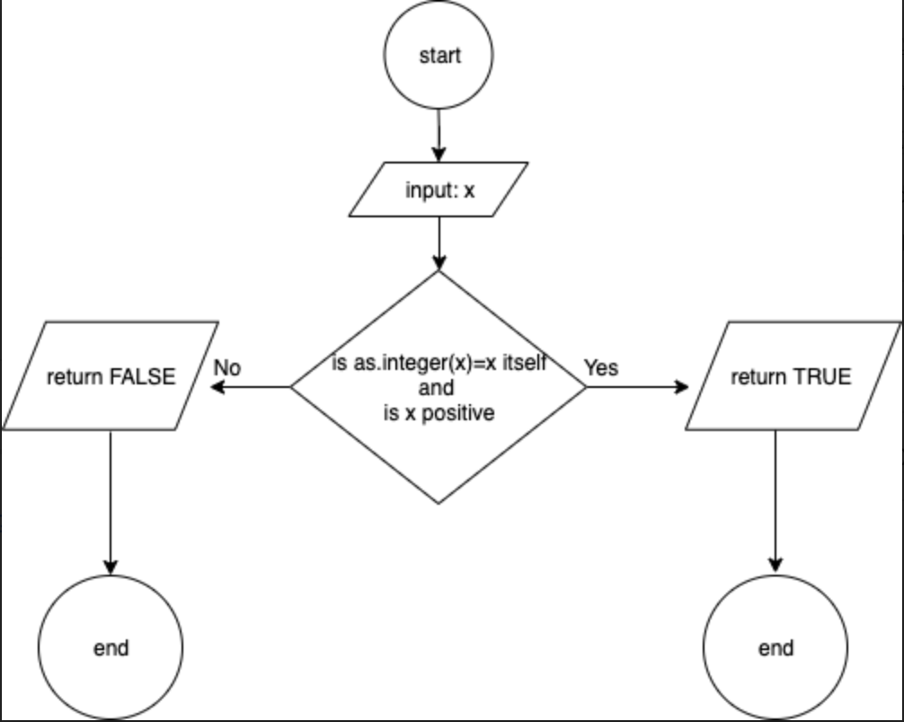

Question 1- positive integer

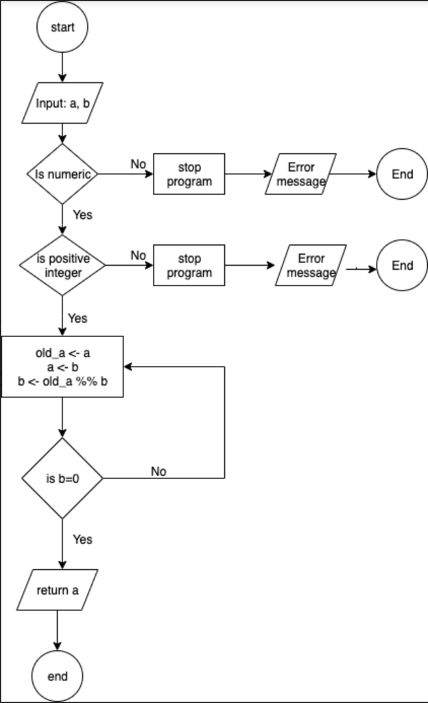

Question 1- GCD function

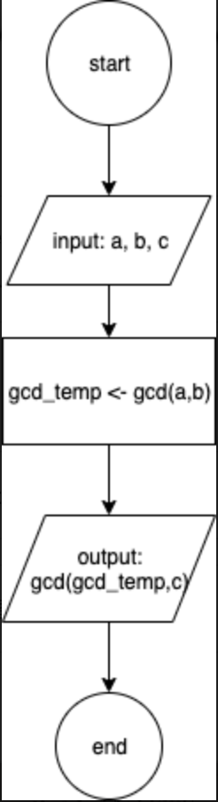

Question 1- gcd_3 function

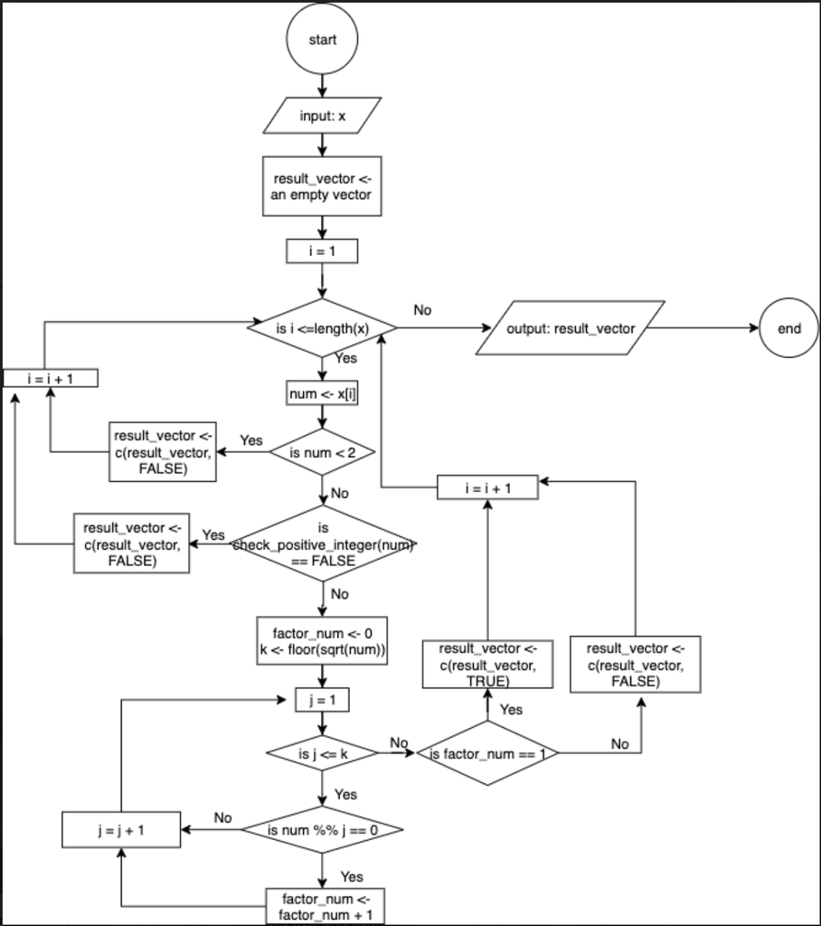

Question 2- is_prime function

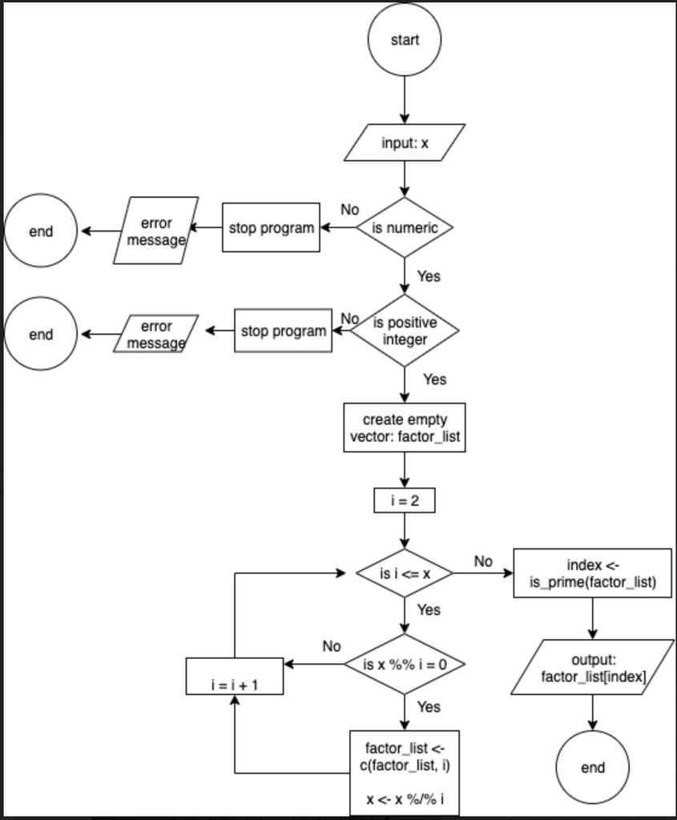

Question 2- get_factors function